# HW 2: Маркетинговая компания

Маматова Агата, aomamatova

## Задача

Для того, чтобы запустить новую маркетинговую кампанию, необходимо проанализировать результаты предыдущих кампаний, изучить данные о клиентах и выявить взаимосвязи между данными и готовностью пользователя откликнуться на кампанию.

### Загрузка данных и преобразование

```r
library(rpart)
library(rpart.plot)
library(dplyr)
library(ggplot2)
library(magrittr)
library(coin)
marketing = read.csv("~/shared/minor2_2021/1-Intro/hw2/marketing_campaign.csv")
```

Преобразование переменных и создание новой колонки.

Немного изучим данные и посмотрим, как соотносятся между собой годовой доход клиента и сумма его покупок по всем товарам среди тех, кто готов откликнуться на кампанию и среди тех, кто не готов.

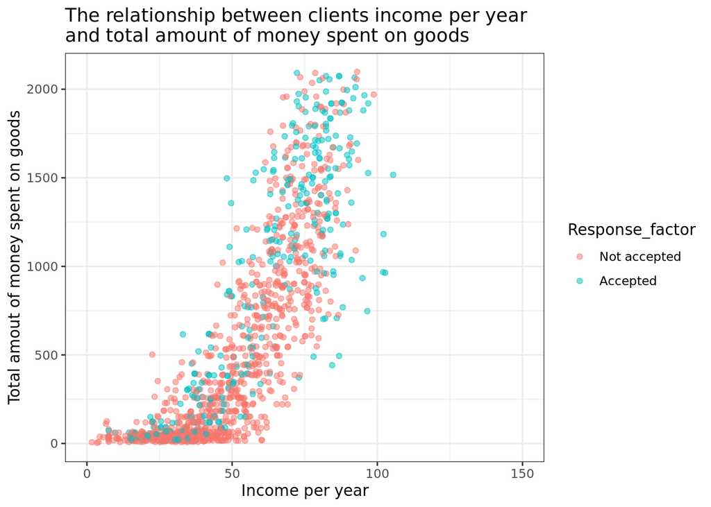

Можем сделать вывод о том, что в среднем большинство клиентов с годовым доходом менее 60000 тратят минимальную сумму на все виды покупок, и для этой категории людей чаще характерно отсутствие готовности откликнуться на кампанию. При этом среди клиентов с годовым доходом от 50000 до 100000 заметна тенденция к увеличению суммы покупок на все представленные товары, и для этой категории людей, особенно для тех, кто суммарно за 2 года приобрел в компании товары на 1500-2000, чаще характерна готовность откликнуться на кампанию.

### Исследовательские вопросы и тесты

**Исследовательский вопрос 1:** верно ли, что пользователи, которые писали жалобу, чаще не готовы откликнуться на новую кампанию?

H0: нет связи между тем, писал ли пользователь жалобу или нет и его готовностью откликнуться на новую кампанию.

H1: есть связь между тем, писал ли пользователь жалобу или нет и его готовностью откликнуться на новую кампанию.

```
##
##                    Not accepted Accepted
##   Complain                   10        3
##   Did not complain          990      331
```

```
##
##  Asymptotic General Independence Test
##
## data:  Response by Complain
## Z = 0.16391, p-value = 0.8698
## alternative hypothesis: two.sided
```

Значение p-value равно 0.8698, поскольку это значение больше чем 0.05, то у нас нет оснований отвергнуть нулевую гипотезу о том, что нет связи между тем, написал пользователь жалобу или нет, и его готовностью откликнуться на кампанию.

**Ответ на исследовательский вопрос:** поскольку нет явной взаимосвязи, мы не можем утверждать, что пользователи, которые писали жалобу, чаще не готовы откликнуться на новую кампанию. Нет, не верно.

**Исследовательский вопрос 2:** связана ли сумма, потраченная на вино, фрукты, мясо, рыбу, сладости с готовностью откликнуться на кампанию?

H0: нет связи между суммой, потраченной на вино, фрукты, мясо, рыбу и сладости и готовностью пользователя откликнуться на кампанию

H1: есть связь между суммой, потраченной на вино, фрукты, мясо, рыбу и сладости и готовностью пользователя откликнуться на кампанию

```
##
##  Welch Two Sample t-test
##
## data:  MntTotal by Response
## t = -10.43, df = 470.77, p-value < 2.2e-16
## alternative hypothesis: true difference in means is not equal to 0
## 95 percent confidence interval:
##  -518.1941 -353.8981
## sample estimates:
## mean in group 0 mean in group 1
##        489.9000        925.9461
```

P-value близко к 0 и меньше 0.05, следовательно мы можем отвергнуть нулевую гипотезу в пользу H1. Кроме того, мы видим, что средняя сумма покупок для тех, кто не готов откликнуться на кампанию составляет 489.9, а для тех, кто готов откликнуться на кампанию средняя сумма оставляет 925.9, что означает, что люди, которые тратят большую сумму на товары, чаще склонны откликнуться на кампанию.

**Ответ на исследовательский вопрос:** да, есть несильная связь между общей суммой покупок пользователя и его готовностью откликнуться на кампанию.

**Исследовательский вопрос 3:** правда ли, что пользователи с более высоким доходом чаще готовы откликнуться на кампанию?

H0: нет связи между величиной дохода и готовностью откликнуться на кампанию

H1: есть связь между величиной дохода и готовностью откликнуться на кампанию

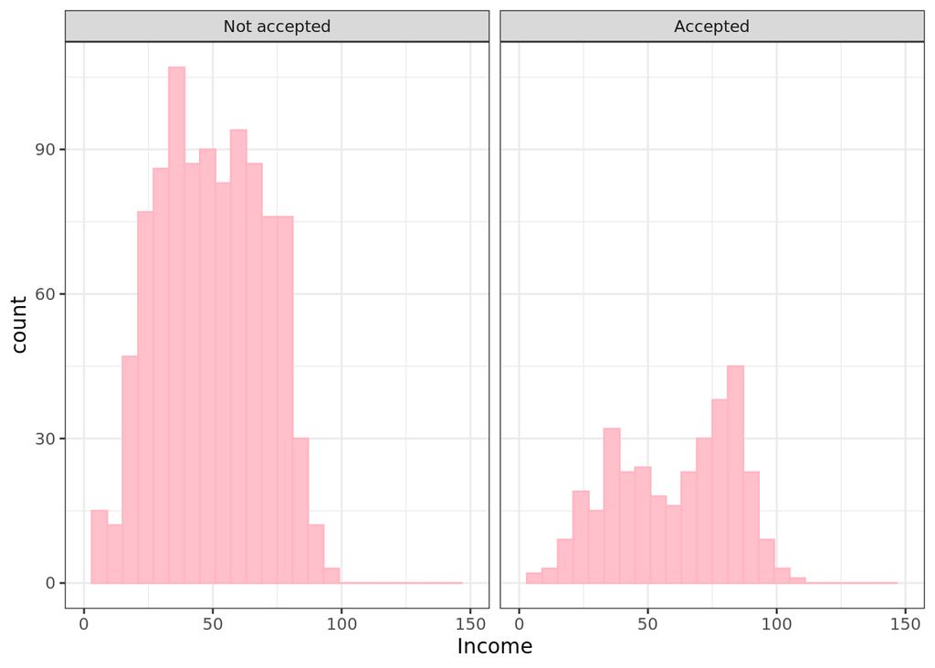

```
##
##  Welch Two Sample t-test
##
## data:  Income by Response
## t = -6.1465, df = 709.6, p-value = 1.321e-09
## alternative hypothesis: true difference in means is not equal to 0
## 95 percent confidence interval:
##  -12.746821  -6.575074
## sample estimates:
## mean in group 0 mean in group 1
##        50.54873        60.20968
```

Поскольку p-value меньше 0.05, мы можем отвергнуть нулевую гипотезу и утверждать, что есть связь между уровнем дохода и готовностью пользователя откликнуться на кампанию. Средний уровень дохода для тех, кто не готов откликнуться на кампанию составляет 50549, что примерно на 10000 меньше, чем средний уровень дохода среди тех, кто готов откликнуться на кампанию.

**Ответ на исследовательский вопрос:** да, есть несильная взаимосвязь между уровнем дохода и готовностью откликнуться на кампанию: в среднем годовой доход выше у тех, кто готов откликнуться на кампанию.

**Исследовательский вопрос 4:** связана ли давность совершения последней покупки с готовностью пользователя откликнуться на кампанию?

H0: нет связи между давностью совершения покупки и готовностью пользователя откликнуться на кампанию H1: есть связь между давностью совершения покупки и готовностью пользователя откликнуться на кампанию

```
##
##  Welch Two Sample t-test
##
## data:  Recency by Response
## t = 9.605, df = 589.95, p-value < 2.2e-16
## alternative hypothesis: true difference in means is not equal to 0
## 95 percent confidence interval:
##  13.48316 20.41437
## sample estimates:
## mean in group 0 mean in group 1
##        52.33200        35.38323
```

P-value близко к 0 и меньше 0.05, следовательно мы можем отвергнуть нулевую гипотезу в пользу H1. Кроме того, мы видим, что пользователи, которые не готовы откликнуться на кампанию, совершали покупку в среднем 52 дня назад, а пользователи, которые готовы откликнуться на кампанию - в среднем всего 35 дней назад. Это означает, что клиенты, которые чаще совершают покупки, чаще склонны откликнуться на кампанию.

**Ответ на исследовательский вопрос:** да, есть связь между давностью совершения покупок клиентом и его готовностью откликнуться на кампанию.

H0: нет связи между предыдщуим и последующим откликом пользователя H1: есть связь между предыдщуим и последующим откликом пользователя

```
##
##                Not accepted Accepted
##   Not accepted          964      242
##   Accepted               36       92
```

### Предсказание отклика на кампанию

Построим дерево, которое будет предстказывать отклик на кампанию по тем переменным, которые мы исследовали.

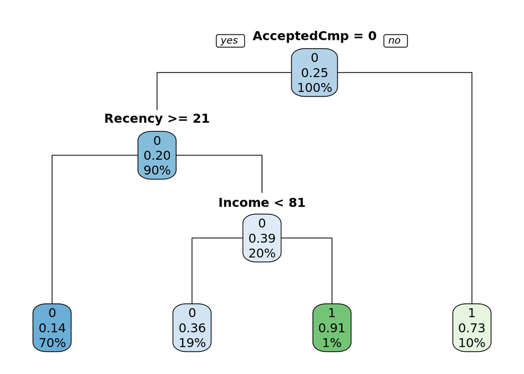

```
## 1 2 3 4 5 6
## 0 0 1 0 0 0
## Levels: 0 1
```

```
## [1] 0.7715356
```

С помощью функции printcp() было подсчитано наиболее подходящее значение cp. Дерево построено по переменным AcceptedCmp, Recency и Income и его точность составляет 0.7715356, что неидеально, но близко к 80%. Не были использованы перемнные Complain, MntTotal, что означает, что они несущественно влияют на результат предсказания.

## Общие выводы

В целом при проведении новой маркетинговой кампании стоит обращать внимание на то, принимал ли клиент участие в предыдущих кампаниях, на то, как давно он совершал покупки в последний раз и на величину его ежегодного дохода.

Компании есть над чем поработать, так как менее одной трети пользователей приняли были готовы откликнуться на последнюю кампанию. Возможно, стоит учитывать и другие переменные при построении дерева, такие как общая сумма покупок по всем товарам, семейный статус, возраст, способ покупки.

Интересно, что не наблюдается сильной связи между написанием пользователем жалобы и готовностью откликнуться на кампанию - я интуитивно ожидала несколько другой результат.